# Homework 1

### Taihua Li | CSC 478 | Homework 1 | 4/14/16

```python
cd "/Users/TaihuaLi/Desktop/DePaul/CSC478 Programming Data Mining Apps/Homework/Homework 1"
```

```
/Users/TaihuaLi/Desktop/DePaul/CSC478 Programming Data Mining Apps/Homework/Homework 1
```

```python
import numpy as np
import pandas as pd
import matplotlib.pyplot as plt
%matplotlib inline
dat = pd.read_csv("bank_data.csv", sep=',', index_col=0)
```

##### 1. Explore the general characteristics of the data as a whole: examine the means, standard deviations, and other statistics associated with the numerical attributes; show the distribution of values associated with categorical attributes, etc.

```python
dat.head(5)
```

| id | age | income | children | gender | region | married | car | savings_acct | current_acct | mortgage | pep |
| --- | --- | --- | --- | --- | --- | --- | --- | --- | --- | --- | --- |
| ID12101 | 48 | 17546.0 | 1 | FEMALE | INNER_CITY | NO | NO | NO | NO | NO | YES |
| ID12102 | 40 | 30085.1 | 3 | MALE | TOWN | YES | YES | NO | YES | YES | NO |
| ID12103 | 51 | 16575.4 | 0 | FEMALE | INNER_CITY | YES | YES | YES | YES | NO | NO |
| ID12104 | 23 | 20375.4 | 3 | FEMALE | TOWN | YES | NO | NO | YES | NO | NO |
| ID12105 | 57 | 50576.3 | 0 | FEMALE | RURAL | YES | NO | YES | NO | NO | NO |

```python
dat.describe(include="all")
```

|  | age | income | children | gender | region | married | car | savings_acct | current_acct | mortgage | pep |
| --- | --- | --- | --- | --- | --- | --- | --- | --- | --- | --- | --- |
| count | 600.000000 | 600.000000 | 600.000000 | 600 | 600 | 600 | 600 | 600 | 600 | 600 | 600 |
| unique | NaN | NaN | NaN | 2 | 4 | 2 | 2 | 2 | 2 | 2 | 2 |
| top | NaN | NaN | NaN | MALE | INNER_CITY | YES | NO | YES | YES | NO | NO |
| freq | NaN | NaN | NaN | 300 | 269 | 396 | 304 | 414 | 455 | 391 | 326 |
| mean | 42.395000 | 27524.031217 | 1.011667 | NaN | NaN | NaN | NaN | NaN | NaN | NaN | NaN |
| std | 14.424947 | 12899.468246 | 1.056752 | NaN | NaN | NaN | NaN | NaN | NaN | NaN | NaN |
| min | 18.000000 | 5014.210000 | 0.000000 | NaN | NaN | NaN | NaN | NaN | NaN | NaN | NaN |
| 25% | 30.000000 | 17264.500000 | 0.000000 | NaN | NaN | NaN | NaN | NaN | NaN | NaN | NaN |
| 50% | 42.000000 | 24925.300000 | 1.000000 | NaN | NaN | NaN | NaN | NaN | NaN | NaN | NaN |
| 75% | 55.250000 | 36172.675000 | 2.000000 | NaN | NaN | NaN | NaN | NaN | NaN | NaN | NaN |
| max | 67.000000 | 63130.100000 | 3.000000 | NaN | NaN | NaN | NaN | NaN | NaN | NaN | NaN |

Numeric variables:

age: The mean is 42.395 years old and the standard deviation is 14.425 years old. The range of age is between 18 and 67 years old while the 25% quantile is at 30 years old, the 50% quantile is at 42 years and the 75% quantile is at 55.25 years old.

children: The mean is 1 child and the standard deviation is also 1 child. The range children is between 0 and 3 children while the 25% quantile is at zero child, the 50% quantile is at 1 child and 75% quantile is at 2 children.

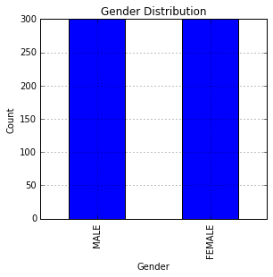

```python
fig = plt.figure(figsize=(10,4))
ax1 = fig.add_subplot(121)
ax1.set_title("Gender Distribution")
ax1.set_xlabel('Gender')
ax1.set_ylabel('Count')
dat.gender.value_counts().plot(kind='bar', grid=True)
```

As shown above, the distribution between male and female is evenly distributed, meaning each gender has 300 instances.

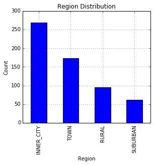

```python
fig = plt.figure(figsize=(10,4))
ax1 = fig.add_subplot(121)
ax1.set_title("Region Distribution")
ax1.set_xlabel('Region')
ax1.set_ylabel('Count')
dat.region.value_counts().plot(kind='bar', grid=True)
```

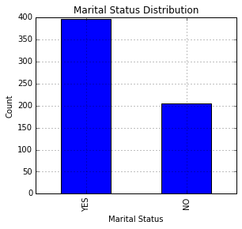

```python
fig = plt.figure(figsize=(10,4))
ax1 = fig.add_subplot(121)
ax1.set_title("Marital Status Distribution")
ax1.set_xlabel('Marital Status')
ax1.set_ylabel('Count')
dat.married.value_counts().plot(kind='bar', grid=True)
```

As shown above, 396 instances are married.

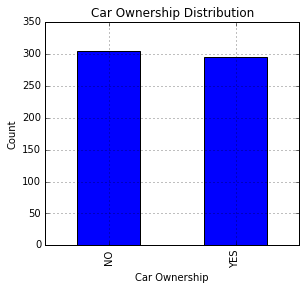

```python
fig = plt.figure(figsize=(10,4))
ax1 = fig.add_subplot(121)
ax1.set_title("Car Ownership Distribution")
ax1.set_xlabel('Car Ownership')
ax1.set_ylabel('Count')
dat.car.value_counts().plot(kind='bar', grid=True)
```

As shown above, 304 instances do not own a car while the rest of 296 instances do.

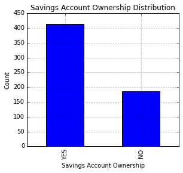

```python
fig = plt.figure(figsize=(10,4))
ax1 = fig.add_subplot(121)
ax1.set_title("Savings Account Ownership Distribution")
ax1.set_xlabel('Savings Account Ownership')
ax1.set_ylabel('Count')
dat.savings_acct.value_counts().plot(kind='bar', grid=True)
```

As shown above, 414 instances have a savings account while the rest do not have one.

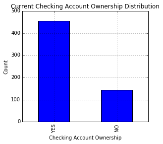

```python
fig = plt.figure(figsize=(10,4))
ax1 = fig.add_subplot(121)
ax1.set_title("Current Checking Account Ownership Distribution")
ax1.set_xlabel('Checking Account Ownership')
ax1.set_ylabel('Count')
dat.current_acct.value_counts().plot(kind='bar', grid=True)
```

As shown above, 455 instances have an current checking account while the other 145 do not have one.

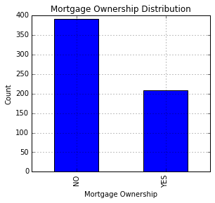

```python
fig = plt.figure(figsize=(10,4))
ax1 = fig.add_subplot(121)
ax1.set_title("Mortgage Ownership Distribution")
ax1.set_xlabel('Mortgage Ownership')
ax1.set_ylabel('Count')
dat.mortgage.value_counts().plot(kind='bar', grid=True)
```

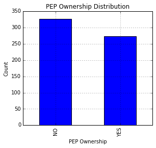

```python
fig = plt.figure(figsize=(10,4))
ax1 = fig.add_subplot(121)
ax1.set_title("PEP Ownership Distribution")
ax1.set_xlabel('PEP Ownership')
ax1.set_ylabel('Count')
dat.pep.value_counts().plot(kind='bar', grid=True)
```

##### 2. Suppose that because of the bank is particularly interested in customers who buy the PEP (Personal Equity Plan) product. Compare and contrast the subsets of customers who buy and don't buy the PEP. Compute summaries (as in part 1) of the selected data with respect to all other attributes. Can you observe any significant differences between these segments of customers? Discuss your observations.

```python
pep_yes = dat[dat.pep=="YES"]
pep_no = dat[dat.pep=="NO"]
```

```python
pep_yes.describe(include="all")
```

|  | age | income | children | gender | region | married | car | savings_acct | current_acct | mortgage | pep |
| --- | --- | --- | --- | --- | --- | --- | --- | --- | --- | --- | --- |
| count | 274.000000 | 274.000000 | 274.000000 | 274 | 274 | 274 | 274 | 274 | 274 | 274 | 274 |
| unique | NaN | NaN | NaN | 2 | 4 | 2 | 2 | 2 | 2 | 2 | 1 |
| top | NaN | NaN | NaN | MALE | INNER_CITY | YES | YES | YES | YES | NO | YES |
| freq | NaN | NaN | NaN | 144 | 123 | 154 | 138 | 179 | 211 | 182 | 274 |
| mean | 45.127737 | 30644.919453 | 0.945255 | NaN | NaN | NaN | NaN | NaN | NaN | NaN | NaN |
| std | 14.327991 | 13609.613043 | 0.860571 | NaN | NaN | NaN | NaN | NaN | NaN | NaN | NaN |
| min | 18.000000 | 7756.360000 | 0.000000 | NaN | NaN | NaN | NaN | NaN | NaN | NaN | NaN |
| 25% | 34.000000 | 19639.475000 | 0.000000 | NaN | NaN | NaN | NaN | NaN | NaN | NaN | NaN |
| 50% | 45.000000 | 28080.050000 | 1.000000 | NaN | NaN | NaN | NaN | NaN | NaN | NaN | NaN |
| 75% | 58.000000 | 38458.350000 | 1.000000 | NaN | NaN | NaN | NaN | NaN | NaN | NaN | NaN |
| max | 67.000000 | 63130.100000 | 3.000000 | NaN | NaN | NaN | NaN | NaN | NaN | NaN | NaN |

```python
pep_no.describe(include="all")
```

|  | age | income | children | gender | region | married | car | savings_acct | current_acct | mortgage | pep |
| --- | --- | --- | --- | --- | --- | --- | --- | --- | --- | --- | --- |
| count | 326.000000 | 326.000000 | 326.000000 | 326 | 326 | 326 | 326 | 326 | 326 | 326 | 326 |
| unique | NaN | NaN | NaN | 2 | 4 | 2 | 2 | 2 | 2 | 2 | 1 |
| top | NaN | NaN | NaN | FEMALE | INNER_CITY | YES | NO | YES | YES | NO | NO |
| freq | NaN | NaN | NaN | 170 | 146 | 242 | 168 | 235 | 244 | 209 | 326 |
| mean | 40.098160 | 24900.953374 | 1.067485 | NaN | NaN | NaN | NaN | NaN | NaN | NaN | NaN |
| std | 14.123506 | 11661.123422 | 1.195524 | NaN | NaN | NaN | NaN | NaN | NaN | NaN | NaN |
| min | 18.000000 | 5014.210000 | 0.000000 | NaN | NaN | NaN | NaN | NaN | NaN | NaN | NaN |
| 25% | 27.000000 | 15366.475000 | 0.000000 | NaN | NaN | NaN | NaN | NaN | NaN | NaN | NaN |
| 50% | 40.000000 | 23105.000000 | 0.000000 | NaN | NaN | NaN | NaN | NaN | NaN | NaN | NaN |
| 75% | 51.000000 | 31210.900000 | 2.000000 | NaN | NaN | NaN | NaN | NaN | NaN | NaN | NaN |
| max | 67.000000 | 61554.600000 | 3.000000 | NaN | NaN | NaN | NaN | NaN | NaN | NaN | NaN |

There are a few significant differences between these two groups. First, the majority of population who purchase the PEP is male while about 52.15% (calculated as 170/326) of the population who do not purchase the PEP are female. Second, in general, the income of population who purchase PEP is higher than those who do not purchase PEP. Comparing the average income between these groups, the income of the group who buy PEP is $5,743.97 (calculated as 30644.92-24900.95) higher than the other group. Also, the average age of the group who buy PEP is 5 years older than the other group. In sum, the population who buy PEP are mostly male and the income of this population is generally higher than the the group who do not buy PEP while the population who buy PEP is genearlly older than the other group.

##### 3. Use z-score normalization to standardize the values of the income attribute. [Do not change the original income attribute in the table.]

```python
inc_mean = dat["income"].mean()
inc_std = dat["income"].std()
```

```python
inc_norm = (dat["income"]-inc_mean)/inc_std
inc_norm.head(5)
```

```
id
ID12101   -0.773523
ID12102    0.198541
ID12103   -0.848766
ID12104   -0.554180
ID12105    1.787071
Name: income, dtype: float64
```

##### 4. Discretize the age attribute into 3 categories (corresponding to "young", "mid-age", and "old"). [Do not change the original age attribute in the table.]

```python
age_bins = pd.qcut(dat.age, [0, 0.33, 0.66, 1], labels=['young', 'mid-age', 'old'], retbins=True)
age_bins
```

```
(id
 ID12101    mid-age
 ID12102    mid-age
 ID12103        old
 ID12104      young
 ID12105        old
 ID12106        old
 ID12107      young
 ID12108        old
 ID12109    mid-age
 ID12110        old
 ID12111        old
 ID12112        old
 ID12113    mid-age
 ID12114        old
 ID12115    mid-age
 ID12116    mid-age
 ID12117    mid-age
 ID12118    mid-age
 ID12119        old
 ID12120      young
 ID12121        old
 ID12122        old
 ID12123        old
 ID12124      young
 ID12125      young
 ID12126        old
 ID12127    mid-age
 ID12128    mid-age
 ID12129    mid-age
 ID12130        old
             ...
 ID12671    mid-age
 ID12672    mid-age
 ID12673      young
 ID12674    mid-age
 ID12675    mid-age
 ID12676    mid-age
 ID12677      young
 ID12678        old
```

[output cut: 10 more lines]

```
 ID12689        old
 ID12690      young
 ID12691      young
 ID12692    mid-age
 ID12693    mid-age
 ID12694        old
 ID12695        old
 ID12696        old
 ID12697      young
 ID12698      young
 ID12699      young
 ID12700    mid-age
 Name: age, dtype: category
 Categories (3, object): [young < mid-age < old],
 array([ 18.,  35.,  49.,  67.]))
```

##### 5. Use Min-Max Normalization to transform the values of all numeric attributes in the original table (income, age, children) onto the range 0.0-1.0.

```python
dat_numeric = dat[['income', 'age', 'children']]
min_max_norm = lambda x: (x - min(x)) / (max(x)-min(x))
norm_numeric = dat_numeric.apply(min_max_norm)
norm_numeric.describe()
```

|  | income | age | children |
| --- | --- | --- | --- |
| count | 600.000000 | 600.000000 | 600.000000 |
| mean | 0.387326 | 0.497857 | 0.337222 |
| std | 0.221961 | 0.294387 | 0.352251 |
| min | 0.000000 | 0.000000 | 0.000000 |
| 25% | 0.210791 | 0.244898 | 0.000000 |
| 50% | 0.342610 | 0.489796 | 0.333333 |
| 75% | 0.536144 | 0.760204 | 0.666667 |
| max | 1.000000 | 1.000000 | 1.000000 |

##### 6. Convert the table (after normalization in part 5) into the standard spreadsheet format. Note that this requires converting each categorical attribute into multiple binary ("dummy") attributes (one for each values of the categorical attribute) and assigning binary values corresponding to the presence or not presence of the attribute value in the original record). Then numeric attributes should remain unchanged. Save this new table into a file called bank_numeric.csv and submitit along with your assignment. [Hint: you might consider using the get_dummies for Pandas data frames.]

```python
new_table = pd.get_dummies(dat)
new_table.to_csv("bank_numeric.csv", float_format="%1.2f")
new_table.head(5)
```

| id | age | income | children | gender_FEMALE | gender_MALE | region_INNER_CITY | region_RURAL | region_SUBURBAN | region_TOWN | married_NO | ... | car_NO | car_YES | savings_acct_NO | savings_acct_YES | current_acct_NO | current_acct_YES | mortgage_NO | mortgage_YES | pep_NO | pep_YES |
| --- | --- | --- | --- | --- | --- | --- | --- | --- | --- | --- | --- | --- | --- | --- | --- | --- | --- | --- | --- | --- | --- |
| ID12101 | 48 | 17546.0 | 1 | 1 | 0 | 1 | 0 | 0 | 0 | 1 | ... | 1 | 0 | 1 | 0 | 1 | 0 | 1 | 0 | 0 | 1 |
| ID12102 | 40 | 30085.1 | 3 | 0 | 1 | 0 | 0 | 0 | 1 | 0 | ... | 0 | 1 | 1 | 0 | 0 | 1 | 0 | 1 | 1 | 0 |
| ID12103 | 51 | 16575.4 | 0 | 1 | 0 | 1 | 0 | 0 | 0 | 0 | ... | 0 | 1 | 0 | 1 | 0 | 1 | 1 | 0 | 1 | 0 |
| ID12104 | 23 | 20375.4 | 3 | 1 | 0 | 0 | 0 | 0 | 1 | 0 | ... | 1 | 0 | 1 | 0 | 0 | 1 | 1 | 0 | 1 | 0 |
| ID12105 | 57 | 50576.3 | 0 | 1 | 0 | 0 | 1 | 0 | 0 | 0 | ... | 1 | 0 | 0 | 1 | 1 | 0 | 1 | 0 | 1 | 0 |

5 rows × 21 columns

##### 7. Using the standardized data set (of the previous part), perform basic correlation analysis among the attributes. Discuss your results by indicating any significant positive or negative correlations among pairs of attributes. You need to construct a complete Correlation Matrix. Be sure to first remove the Customer ID column before creating the correlation matrix. [Hint: you can do this by using the corr() function in Pandas or corrcoef function in NumPy].

```python
new_table.corr()
```

|  | age | income | children | gender_FEMALE | gender_MALE | region_INNER_CITY | region_RURAL | region_SUBURBAN | region_TOWN | married_NO | ... | car_NO | car_YES | savings_acct_NO | savings_acct_YES | current_acct_NO | current_acct_YES | mortgage_NO | mortgage_YES | pep_NO | pep_YES |
| --- | --- | --- | --- | --- | --- | --- | --- | --- | --- | --- | --- | --- | --- | --- | --- | --- | --- | --- | --- | --- | --- |
| age | 1.000000 | 0.752726 | 0.023572 | 0.090081 | -0.090081 | -0.025171 | 0.018635 | 0.031345 | -0.008510 | -0.010394 | ... | -0.077733 | 0.077733 | -0.184389 | 0.184389 | 0.035312 | -0.035312 | 0.016154 | -0.016154 | -0.173825 | 0.173825 |
| income | 0.752726 | 1.000000 | 0.036761 | 0.023845 | -0.023845 | -0.047564 | 0.084776 | 0.029824 | -0.036431 | 0.008386 | ... | -0.081556 | 0.081556 | -0.266164 | 0.266164 | -0.031616 | 0.031616 | 0.014662 | -0.014662 | -0.221991 | 0.221991 |
| children | 0.023572 | 0.036761 | 1.000000 | 0.014206 | -0.014206 | -0.051222 | 0.089902 | -0.014122 | -0.007033 | 0.048716 | ... | -0.036455 | 0.036455 | -0.041536 | 0.041536 | -0.006238 | 0.006238 | 0.074339 | -0.074339 | 0.057663 | -0.057663 |
| gender_FEMALE | 0.090081 | 0.023845 | 0.014206 | 1.000000 | -1.000000 | -0.023459 | -0.009092 | -0.010951 | 0.040472 | 0.021110 | ... | 0.006667 | -0.006667 | 0.007207 | -0.007207 | -0.019466 | 0.019466 | 0.066465 | -0.066465 | 0.046843 | -0.046843 |
| gender_MALE | -0.090081 | -0.023845 | -0.014206 | -1.000000 | 1.000000 | 0.023459 | 0.009092 | 0.010951 | -0.040472 | -0.021110 | ... | -0.006667 | 0.006667 | -0.007207 | 0.007207 | 0.019466 | -0.019466 | -0.066465 | 0.066465 | -0.046843 | 0.046843 |
| region_INNER_CITY | -0.025171 | -0.047564 | -0.051222 | -0.023459 | 0.023459 | 1.000000 | -0.393444 | -0.306032 | -0.573814 | -0.003254 | ... | 0.018143 | -0.018143 | 0.091373 | -0.091373 | -0.007894 | 0.007894 | -0.002098 | 0.002098 | -0.001054 | 0.001054 |
| region_RURAL | 0.018635 | 0.084776 | 0.089902 | -0.009092 | 0.009092 | -0.393444 | 1.000000 | -0.148158 | -0.277798 | 0.022649 | ... | -0.024006 | 0.024006 | -0.036960 | 0.036960 | 0.008496 | -0.008496 | 0.051908 | -0.051908 | -0.019714 | 0.019714 |
| region_SUBURBAN | 0.031345 | 0.029824 | -0.014122 | -0.010951 | 0.010951 | -0.306032 | -0.148158 | 1.000000 | -0.216080 | -0.012483 | ... | 0.061184 | -0.061184 | -0.002605 | 0.002605 | -0.038157 | 0.038157 | -0.004635 | 0.004635 | -0.062508 | 0.062508 |
| region_TOWN | -0.008510 | -0.036431 | -0.007033 | 0.040472 | -0.040472 | -0.573814 | -0.277798 | -0.216080 | 1.000000 | -0.006369 | ... | -0.041604 | 0.041604 | -0.068654 | 0.068654 | 0.027431 | -0.027431 | -0.036591 | 0.036591 | 0.059115 | -0.059115 |
| married_NO | -0.010394 | 0.008386 | 0.048716 | 0.021110 | -0.021110 | -0.003254 | 0.022649 | -0.012483 | -0.006369 | 1.000000 | ... | -0.009571 | 0.009571 | 0.028604 | -0.028604 | -0.059996 | 0.059996 | -0.021711 | 0.021711 | -0.189578 | 0.189578 |
| married_YES | 0.010394 | -0.008386 | -0.048716 | -0.021110 | 0.021110 | 0.003254 | -0.022649 | 0.012483 | 0.006369 | -1.000000 | ... | 0.009571 | -0.009571 | -0.028604 | 0.028604 | 0.059996 | -0.059996 | 0.021711 | -0.021711 | 0.189578 | -0.189578 |
| car_NO | -0.077733 | -0.081556 | -0.036455 | 0.006667 | -0.006667 | 0.018143 | -0.024006 | 0.061184 | -0.041604 | -0.009571 | ... | 1.000000 | -1.000000 | 0.034310 | -0.034310 | -0.034783 | 0.034783 | -0.007743 | 0.007743 | 0.018917 | -0.018917 |
| car_YES | 0.077733 | 0.081556 | 0.036455 | -0.006667 | 0.006667 | -0.018143 | 0.024006 | -0.061184 | 0.041604 | 0.009571 | ... | -1.000000 | 1.000000 | -0.034310 | 0.034310 | 0.034783 | -0.034783 | 0.007743 | -0.007743 | -0.018917 | 0.018917 |
| savings_acct_NO | -0.184389 | -0.266164 | -0.041536 | 0.007207 | -0.007207 | 0.091373 | -0.036960 | -0.002605 | -0.068654 | 0.028604 | ... | 0.034310 | -0.034310 | 1.000000 | -1.000000 | 0.042511 | -0.042511 | -0.001588 | 0.001588 | -0.072779 | 0.072779 |
| savings_acct_YES | 0.184389 | 0.266164 | 0.041536 | -0.007207 | 0.007207 | -0.091373 | 0.036960 | 0.002605 | 0.068654 | -0.028604 | ... | -0.034310 | 0.034310 | -1.000000 | 1.000000 | -0.042511 | 0.042511 | 0.001588 | -0.001588 | 0.072779 | -0.072779 |
| current_acct_NO | 0.035312 | -0.031616 | -0.006238 | -0.019466 | 0.019466 | -0.007894 | 0.008496 | -0.038157 | 0.027431 | -0.059996 | ... | -0.034783 | 0.034783 | 0.042511 | -0.042511 | 1.000000 | -1.000000 | -0.036704 | 0.036704 | 0.025141 | -0.025141 |
| current_acct_YES | -0.035312 | 0.031616 | 0.006238 | 0.019466 | -0.019466 | 0.007894 | -0.008496 | 0.038157 | -0.027431 | 0.059996 | ... | 0.034783 | -0.034783 | -0.042511 | 0.042511 | -1.000000 | 1.000000 | 0.036704 | -0.036704 | -0.025141 | 0.025141 |
| mortgage_NO | 0.016154 | 0.014662 | 0.074339 | 0.066465 | -0.066465 | -0.002098 | 0.051908 | -0.004635 | -0.036591 | -0.021711 | ... | -0.007743 | 0.007743 | -0.001588 | 0.001588 | -0.036704 | 0.036704 | 1.000000 | -1.000000 | -0.024182 | 0.024182 |
| mortgage_YES | -0.016154 | -0.014662 | -0.074339 | -0.066465 | 0.066465 | 0.002098 | -0.051908 | 0.004635 | 0.036591 | 0.021711 | ... | 0.007743 | -0.007743 | 0.001588 | -0.001588 | 0.036704 | -0.036704 | -1.000000 | 1.000000 | 0.024182 | -0.024182 |
| pep_NO | -0.173825 | -0.221991 | 0.057663 | 0.046843 | -0.046843 | -0.001054 | -0.019714 | -0.062508 | 0.059115 | -0.189578 | ... | 0.018917 | -0.018917 | -0.072779 | 0.072779 | 0.025141 | -0.025141 | -0.024182 | 0.024182 | 1.000000 | -1.000000 |
| pep_YES | 0.173825 | 0.221991 | -0.057663 | -0.046843 | 0.046843 | 0.001054 | 0.019714 | 0.062508 | -0.059115 | 0.189578 | ... | -0.018917 | 0.018917 | 0.072779 | -0.072779 | -0.025141 | 0.025141 | 0.024182 | -0.024182 | -1.000000 | 1.000000 |

21 rows × 21 columns

```python
corr_val=0.6
var_cor = new_table.corr().unstack().reset_index()
var_cor[abs(var_cor[0])>0.6]
```

|  | level_0 | level_1 | 0 |
| --- | --- | --- | --- |
| 0 | age | age | 1.000000 |
| 1 | age | income | 0.752726 |
| 21 | income | age | 0.752726 |
| 22 | income | income | 1.000000 |
| 44 | children | children | 1.000000 |
| 66 | gender_FEMALE | gender_FEMALE | 1.000000 |
| 67 | gender_FEMALE | gender_MALE | -1.000000 |
| 87 | gender_MALE | gender_FEMALE | -1.000000 |
| 88 | gender_MALE | gender_MALE | 1.000000 |
| 110 | region_INNER_CITY | region_INNER_CITY | 1.000000 |
| 132 | region_RURAL | region_RURAL | 1.000000 |
| 154 | region_SUBURBAN | region_SUBURBAN | 1.000000 |
| 176 | region_TOWN | region_TOWN | 1.000000 |
| 198 | married_NO | married_NO | 1.000000 |
| 199 | married_NO | married_YES | -1.000000 |
| 219 | married_YES | married_NO | -1.000000 |
| 220 | married_YES | married_YES | 1.000000 |
| 242 | car_NO | car_NO | 1.000000 |
| 243 | car_NO | car_YES | -1.000000 |
| 263 | car_YES | car_NO | -1.000000 |
| 264 | car_YES | car_YES | 1.000000 |
| 286 | savings_acct_NO | savings_acct_NO | 1.000000 |
| 287 | savings_acct_NO | savings_acct_YES | -1.000000 |
| 307 | savings_acct_YES | savings_acct_NO | -1.000000 |
| 308 | savings_acct_YES | savings_acct_YES | 1.000000 |
| 330 | current_acct_NO | current_acct_NO | 1.000000 |
| 331 | current_acct_NO | current_acct_YES | -1.000000 |
| 351 | current_acct_YES | current_acct_NO | -1.000000 |
| 352 | current_acct_YES | current_acct_YES | 1.000000 |
| 374 | mortgage_NO | mortgage_NO | 1.000000 |
| 375 | mortgage_NO | mortgage_YES | -1.000000 |
| 395 | mortgage_YES | mortgage_NO | -1.000000 |
| 396 | mortgage_YES | mortgage_YES | 1.000000 |
| 418 | pep_NO | pep_NO | 1.000000 |
| 419 | pep_NO | pep_YES | -1.000000 |
| 439 | pep_YES | pep_NO | -1.000000 |
| 440 | pep_YES | pep_YES | 1.000000 |

As shown above, "age" and "income" have a correlation coefficient of 0.7527 which indicates a high positive correlation. Besides this pair of significant correlation, the other significant correlation coefficients are all for relations between dummy variables created from binary variables and they are all perfectly negatively correlated. For example, "gender_MALE" and "gender_FEMALE" have a correlation coefficient of -1.

##### 8. Using Matplotlib library and/or ploting capabilties of Pandas, create a scatter plot of the (non-normalized) Income attribute relative to Age. Be sure that your plot contains appropriate labels for the axes. Do these variables seem correlated?

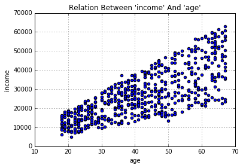

```python
new_table.plot(x="age", y="income", kind="scatter", title="Relation Between 'income' And 'age'", grid=True)
```

Yes. These two variables seem to have a significant positive correlation.

##### 9. Create histograms for (non-normalized) Income (using 9 bins) and Age (using 15 bins).

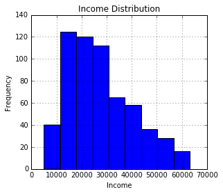

```python
fig = plt.figure(figsize=(10,4))
ax1 = fig.add_subplot(121)
ax1.set_title("Income Distribution")
ax1.set_xlabel('Income')
ax1.set_ylabel('Frequency')
new_table["income"].plot(kind="hist", bins=9, grid=True)
```

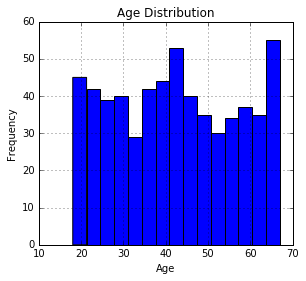

```python
fig = plt.figure(figsize=(10,4))
ax1 = fig.add_subplot(121)
ax1.set_title("Age Distribution")
ax1.set_xlabel('Age')
ax1.set_ylabel('Frequency')
new_table["age"].plot(kind="hist", bins=15, grid=True)
```

##### 10. Using a bargraph, plot the distribution of the values of the region attribute.

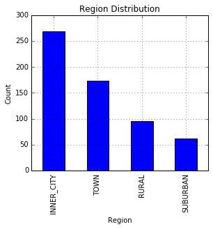

```python
fig = plt.figure(figsize=(10,4))
ax1 = fig.add_subplot(121)
ax1.set_title("Region Distribution")
ax1.set_xlabel('Region')
ax1.set_ylabel('Count')
dat['region'].value_counts().plot(kind="bar", grid=True)
```

##### 11. Perform a cross-tabulation of the region attribute with the pep attribute. This requires the aggregation of the occurrences of each pep value (yes or no) separately for each value of the region attribute. Show the results as a 4 by 2 (region x pep) table with entries representing the counts. [Hint: you can either use Numpy or use aggregations fucntions in Pandas such as groupby() and cross-tab().] Then, either using Matplotlib directly or the plot() function in Pandas create a bar chart graph to visualize of the relationships between these sets of variables.

```python
ct = pd.crosstab(dat['region'], dat['pep'])
ct
```

| pep region | NO | YES |
| --- | --- | --- |
| INNER_CITY | 146 | 123 |
| RURAL | 50 | 46 |
| SUBURBAN | 28 | 34 |
| TOWN | 102 | 71 |

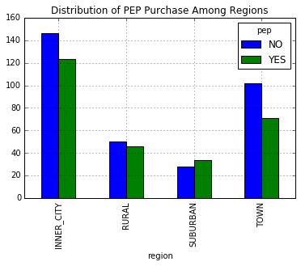

```python
plt.show(ct.plot(kind="bar", grid=True, title="Distribution of PEP Purchase Among Regions"))
```